# VIRGINIA MATH

Virginia Math Bulletin

Edited by Madison Perry

## View From the Chair

The 2020-2021 year was an extraordinary year for our department. We continued our unprecedented struggle with COVID with mixed results. In addition to significant human loss and suffering, we have unexpectedly been forced to transform every aspect of our personal and work lives. Despite growing optimism that a return to "normal life" is near, let’s acknowledge that we have all been hit hard by the pandemic. Some of us have lost family and loved ones. Some of us have contracted COVID. We have all struggled with the negative effects of physical distancing. Universities were never meant to be virtual.

As we move forward, let’s all be aware of the challenges we face: re-establishing community, restoring engagement with our students, supporting our friends and colleagues, etc. Despite the uncertainty of what comes next, I strongly believe that UVA Mathematics will emerge as a beacon of light in our lives.

In spite of COVID, I am proud to report that UVA Mathematics enjoyed a strong year. This newsletter welcomes some new faces, highlights faculty and student achievements and honors, and describes some of the wonderful programs and projects that help define UVA Mathematics. Please enjoy.

Sincerely,

Ken Ono  
UVA Department of Mathematics Chairman

### Supporting Us

The Mathematics Department is grateful for the generous support of its alumni and friends. The Department welcomes gifts annually to address its most urgent needs, as well as to the endowment which provides funding in perpetuity. To learn more about how you can make a difference by supporting the Mathematics Department, please contact Becky Balber at beckybalber@virginia.edu or (434) 243-4978. To make a gift online, please visit http://giving.as.virginia.edu/mathematics.

## New Faculty Profiles

### Joe Webster (Whyburn Research Associate)

Mentor: Abdelmalek Abdesselam

Joe Webster’s work is at the interface of mathematical physics, number theory, probability, and combinatorics. He studied the statistical mechanics of gases of particles which interact in pairs via a potential such as the Coulomb potential of the electrostatic force. Quantities of interest such as the pressure or spatial correlations can typically be obtained as suitable partial derivatives of a master quantity called the partition function. For the systems studied by Webster, namely log-Coulomb gases in $p$-adic spaces which have a built-in hierarchical structure, the partition function can become a Mehta integral as studied in random matrix theory or a local zeta function as studied in number theory. Webster developed a combinatorial technique for the analysis of these partition functions. By looking at a fixed collection of particles with varying scale, one obtains a hierarchy of partitions where the

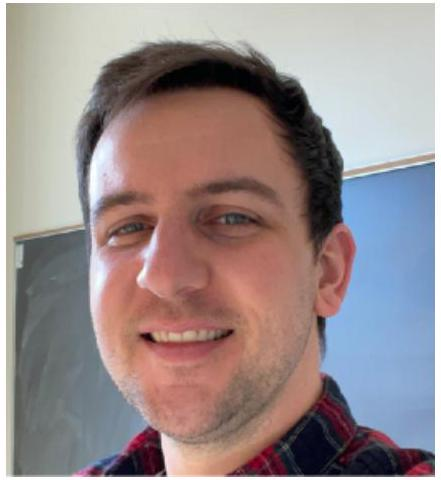

blocks correspond to clusters of particles which, modulo the prevailing resolution, appear to be at the same location. Using this conceptual tool, Webster obtained new formulae and properties of the partitions’ functions. He is now exploring similar questions for other underlying spaces, as well as the connection to other renormalization group theory which earned Kenneth Wilson the Nobel Prize in Physics in 1982. Joe Webster received his bachelors in Mathematics from the University of California Davis in 2013 and his PhD in Mathematics from the University of Oregon Eugene in 2021. This Fall 2021, Webster taught Linear Algebra and is teaching Basic Real Analysis this Spring – a course he’s particularly passionate about since it is the first real opportunity for many students to write proofs in analysis.

### William Balderrama (RTG Research Associate)

Mentor: Nicholas Kuhn

William Balderrama joins the department’s algebraic topology group. His research involves exploring the interactions of equivariant stable homotopy theory (geometry equipped with symmetries and ‘stabilized’) and chromatic homotopy theory (geometry exploiting surprising dimensional periodicities in geometric structure), leading to tools that allow homotopical structure to be accessed by computationally-accessible algebra. He uses modern tools from algebraic geometry, representation theory, and category theory in his work. William received a B.S. from UCLA in 2015 and then a Ph.D. from the University of Illinois at Urbana-Champaign in 2021, advised by Charles Rezk. He is supported by funding from the Geometry and Topology group’s Research Training Grant from the National Science Foundation. Besides teaching during the academic

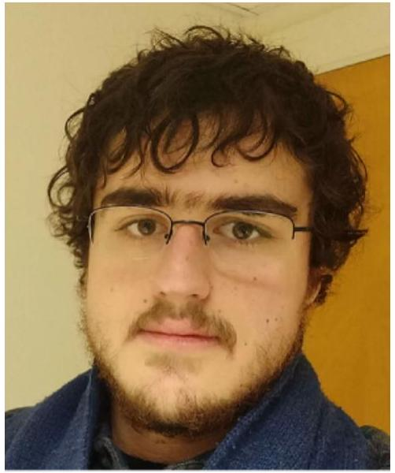

year, he will be assisting in the RTG summer program for undergraduates.

### Liaosha Xu (Research Associate)

Mentor: Zoran Grujic

Liaosha Xu’s research interests are in the areas of partial differential equations, fluid dynamics, harmonic analysis and geometric analysis. His current research concerns a fundamental question in the mathematical fluid dynamics: can the 3D Navier-Stokes (NS) system–describing a motion of 3D, viscous, incompressible, Newtonian fluid–exhibit a spontaneous formation of singularities? A major obstacle to a solution has been the supercriticality of the problem–and in particular–supercriticality with respect to the strength of the diffusion (the NS diffusion is generated by the negative Laplacian, while the classical theory necessitates the negative Laplacian to the power of at least $5/4$ to rule out the singularities). Liaosha has already made a foundational contribution in this realm by demonstrating that any power of the negative Laplacian greater than $1$ rules out a ‘turbulent’ blow-up with no additional assumptions as well as the complementary

‘homogeneous’ blow-up with an assumption that the build-up of a singular profile is ‘focusing’ (one should note that this assumption imposes no condition on the strength of a singularity).

Liaosha received his B.S. in Mathematics from Jilin University (2011), his M.S. in Applied Mathematics from the Illinois Institute of Technology (2013), and his Ph.D. in Mathematics from the University of Virginia (December 2020). He was on a Postdoctoral

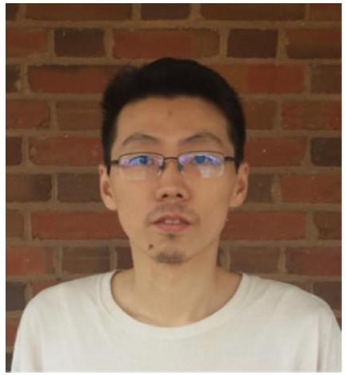

Fellowship at MSRI in Spring 2021, and his current position is funded by the NSF and supplemented by the IMS (our Institute of Mathematical Sciences).

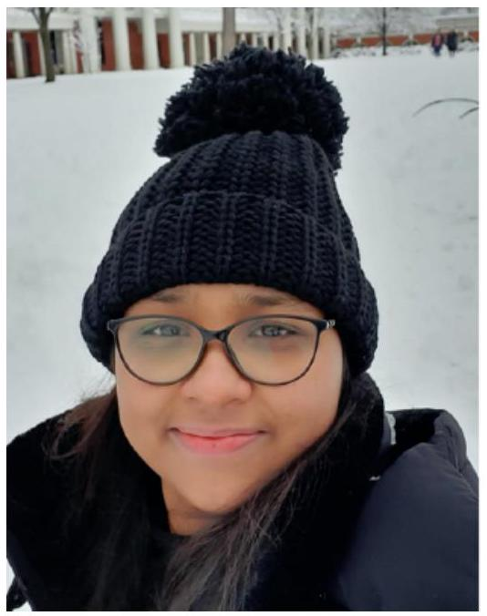

### Neelam Saikia (Visiting Postdoctoral Scholar)

Faculty mentor: Ken Ono

Neelam Saikia is a Nehru-Fulbright Postdoctoral Scholar who works in number theory.

Her interests include the theory of $p$-adic hypergeometric functions, zeta functions of varieties over finite fields, and the theory of modular forms. Saikia has written over 20 papers in journals such as Archiv der Mathematik, Mathematical Proceedings of the Cambridge Philosophical Society, the International Journal of Number Theory, Journal of Number Theory, to name a few. Saikia completed her PhD in 2016 under the direction of Rupam Barman at the Indian Institute of Technology at Delhi. Before coming to UVa, Saikia was a postdoctoral fellow at the Indian Institute of Science in Bangalore.

### Mark Pengitore (RTG Research Associate and Lecturer)

Faculty mentor: Thomas Koberda  
Mark Pengitore works in geometric group theory and low dimensional topology. His interests include effective separability questions in group theory, translation-like actions of groups, and decision problems for finitely generated groups. He is particularly interested in infinite solvable and nilpotent groups, lattices in Lie groups, mapping class groups, and applications of finite groups to the study of infinite groups. Pengitore has published 9 papers in journals such as the Bulletin of the London Mathematical Society, the Journal of Group Theory, and Mathematische Zeitschrift, and has

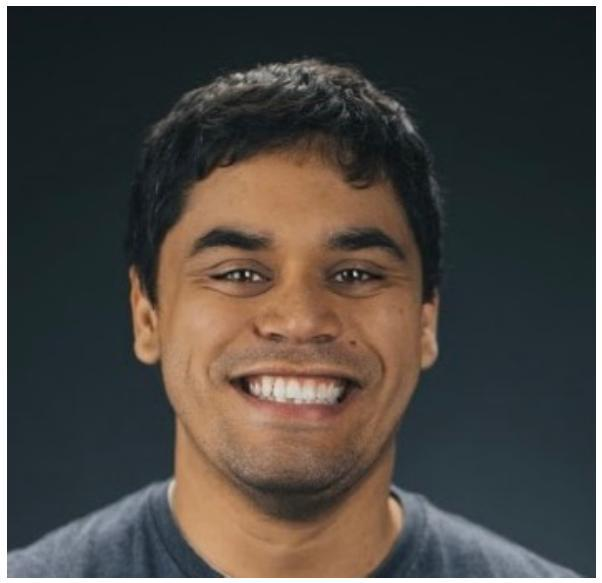

posted a large number of further preprints.  
Pengitore completed his PhD in 2018 at Purdue under Ben McReynolds, and was a Zassenhaus Assistant Professor at the Ohio State University before joining UVa.

### Daniel (DJ) James

Assistant Professor, General Faculty  
(2021- )

DJ received his PhD. from Auburn University in 2017, receiving the Excellence in Teaching award. DJ joined the University of Delaware in 2018 as a temporary Assistant Professor. During his time there, he: worked with graduate students and faculty members to develop the first GTA professional teaching development program in the department and redesigned assessment and active learning materials while coordinating instruction in Calculus III. DJ joined the faculty of University of Kansas in 2020 as an Assistant Teaching Professor.

After receiving a grant to redesign instruction in a hybrid-online course, DJ designed and implemented learning goals and learning-goal-aligned videos, activities, and assessments in large lecture

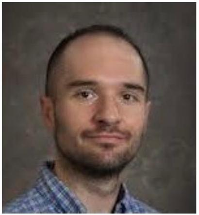

courses. This resulted in some of the lowest DFW rates ever recorded in the course.

Currently DJ is investigating the efficacy of an intervention designed to support metacognition in at-risk students during the course redesign at KU, working to improve how we develop GTAs for teaching at UVa and will be piloting Growth-Based Learning (with Matt Demers) in Math 1310 at UVa.

### Matt Demers

Assistant Professor, General Faculty  
(2021- ) Matt completed his PhD. in 2012 at Northwestern University. He did postdoctoral work in a joint program between MIT and the Singapore University of Technology and Design where he help develop a novel electrorheological pump. Matt moved to Harvard as a Lecturer, then Preceptor from 2015-2021.

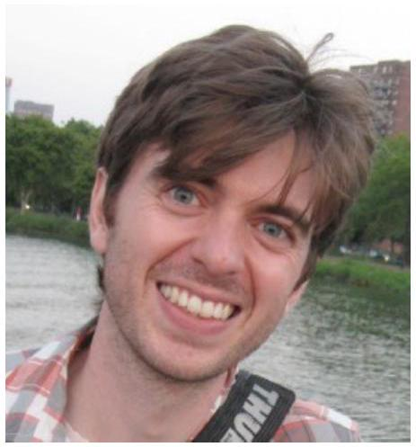

Matt’s current focus is as a math educator. He is interested in using evidence-based practices to help ensure the success of students in the classroom, to mentor developing instructors, and to improve opportunities for students from underrepresented backgrounds. This year Matt is coordinating Math 1190/1210 and is piloting (with Daniel James) Growth-Based Learning in these courses.

## Faculty Awards and Honors

### Weiqiang Wang Invited to Deliver Lecture at ICM 2022

Weiqiang Wang is the Gordon Whyburn Professor of Mathematics at UVa, and he will be giving an invited lecture at the 2022 International Congress of Mathematicians. An invited address at the ICM is generally considered to be among the most prestigious honors available to research mathematicians. Weiqiang’s research interests include representation theory for Lie (super) algebras, quantum groups, Hecke algebras, and Hall algebras. In particular, he is known for the formulation and solution of the super Kazhdan-Lusztig conjecture in type $BCD$ (joint with Huanchen Bao). To achieve this and go beyond, Bao and Wang have generalized Lusztig’s construction of canonical bases for quantum groups to $i$-quantum groups arising from quantum symmetric pairs. In recent years, he has developed  
a Hall algebra approach to $i$-quantum groups (joint with Ming Lu). He and his former graduate student at UVa Huanchen Bao shared the 2020 Chevalley Prize in Lie theory of American Mathematical Society.

Weiqiang was born in Anhui, China, and graduated from the University of Science and Technology of China (B.S.) in 1989, and from the Institute of Mathematics, Academia Sinica (M.S.) in 1991. He obtained his PhD from Massachusetts Institute of Technology in 1995, working under the guidance of Victor Kac. Before joining UVa in 2001, he was an Assistant Professor at North Carolina State University (1999-2001), and has held visiting and postdoctoral positions at Yale University (1996-1999), Max-Planck Institute for Mathematics in Bonn (1997-1998), and Institute of Advanced Study (1995-1996).

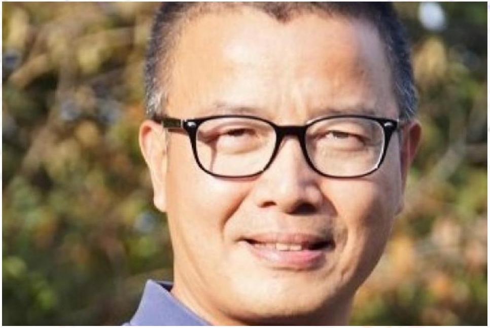

### Koberda and Maloni Named UVA College Fellows

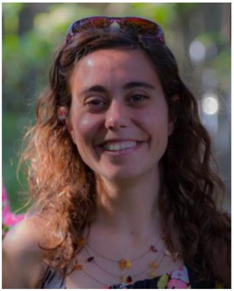

UVA Mathematics is delighted to report that Thomas Koberda and Sara Maloni have been named UVA College Fellows for the AY 2022-24. As the backbone of the New Curriculum, College Fellows are tasked with designing and teaching Engagement courses. The college’s Engagements aim to acquaint students with foundational habits of the mind and to cultivate intellectual sensibilities that span the four disciplinary specializations: Aesthetic

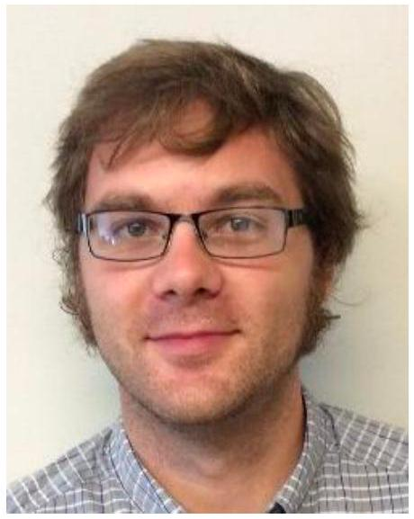

Engagement; Empirical and Scientific Engagement; Engaging Difference; and Ethical Engagement.

### Ono Wins the 2020 UVa Distinguished Spotlight Researcher Award

In a virtual ceremony held over Zoom in January 2021, UVa honored and recognized faculty members for their outstanding contributions to their fields and the impact of their research and scholarly activities. "Our dedicated and talented researchers are deeply committed to the mission of this university—advancing knowledge and passing it on to the world and the next generation," Provost Liz Magill said. "The Research Achievement Awards are a great way to recognize our researchers for making meaningful contributions in their disciplines, supporting their peers and mentees, and having a positive impact on our communities." Ken Ono, Thomas Jefferson Professor of Mathematics, delivered the keynote

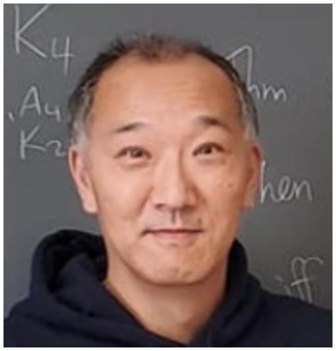

address, and received the 2020 UVa Distinguished Spotlight Researcher Award for his contributions to the field of mathematics. He has won Sloan, Packard and Guggenheim fellowships, and in 2020 Academic Influence named him one of the 15 most influential mathematicians of the past decade. In 2000 he received the Presidential Early Career Award from Bill Clinton at a ceremony at the White House, and in 2005 he was named the NSF Director’s Distinguished Teaching Scholar, an honor he received in a ceremony at the US National Academy of Sciences in Washington, DC.

### Ben Hayes Wins an NSF CAREER Award

The National Science Foundation awarded Assistant Professor Ben Hayes with Early Career Development (CAREER) award. This grant titled "Invariants and Entropy of Square Integrable Functions," is for five years, totaling $400,000. The CAREER award is the "most prestigious awards in support of early-career faculty who have the potential to serve as academic role models in research and education and to lead advances in the mission of their department or organization," according to the organization’s website. Ben Hayes works at the intersection of operator algebras and ergodic theory, specifically how tools and methods from each field can be applied to the other. The research aspect of the grant is related to two projects. The first considers actions by automorphisms of compact, abelian groups,

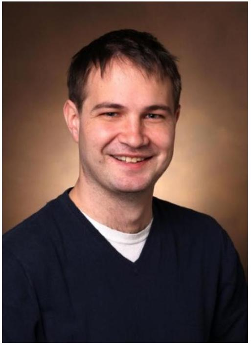

and how the entropy of these actions are related to certain topological invariants defined via von Neumann algebras. Second, Ben plans to adapt methods from entropy theory in dynamical systems to von Neumann algebras, specifically to study invariants for von Neumann algebras which measure "how many" finite-dimensional approximations they have. For the educational aspect of the grant, Ben plans to broaden connections between the department and the math alliance, run two summer schools at UVa on the relations between ergodic theory and operator algebras, and host talks at UVa on how to make classroom and department environments more equitable and inclusive. Ben says that he would like to thank former CAREER winners Julie Bergner and Sara Maloni for their help and advice with writing the grant.

### Jennifer Morse Wins a 2021 Simons Fellowship

Jennifer Morse was named a 2021 Simons Fellow for her research on Diagonal harmonics and Schubert calculus. The Simons Foundation aims to advance discovery in mathematics and the basic sciences by awarding this fellowship to outstanding mathematicians and theoretical physicists; it extends academic leave, allowing time for the fellow to focus exclusively on making significant advances in research.

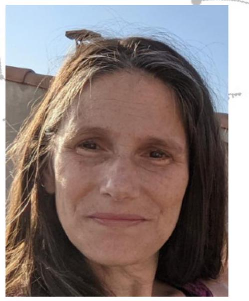

### Jim Rolf Named Advance Fellow

Jim Rolf was named an Advance Fellow by the UVa College of Arts and Sciences Dean’s Office. The appointment recognizes Jim for his commitment to teaching and learning in the Math department and complements his current initiatives supported by the Learning Technology Incubator (LTI) grant Jim received last spring to increase student success in introductory math courses. This three-year appointment places Jim in leadership opportunities across Grounds to impact other faculty and courses.

[figure not shown]

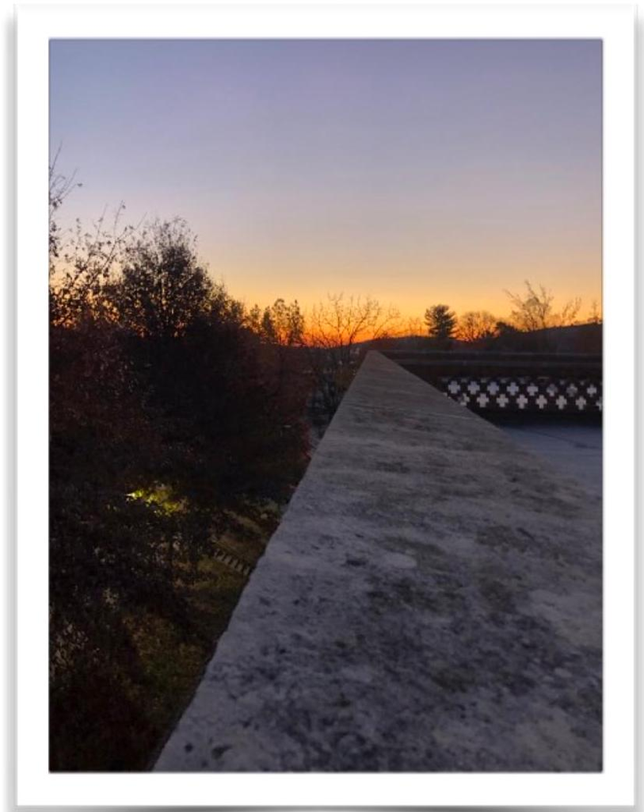

Views from the roof of Kerchof Hall  
Photo credits: Madison Perry and Spencer Martin

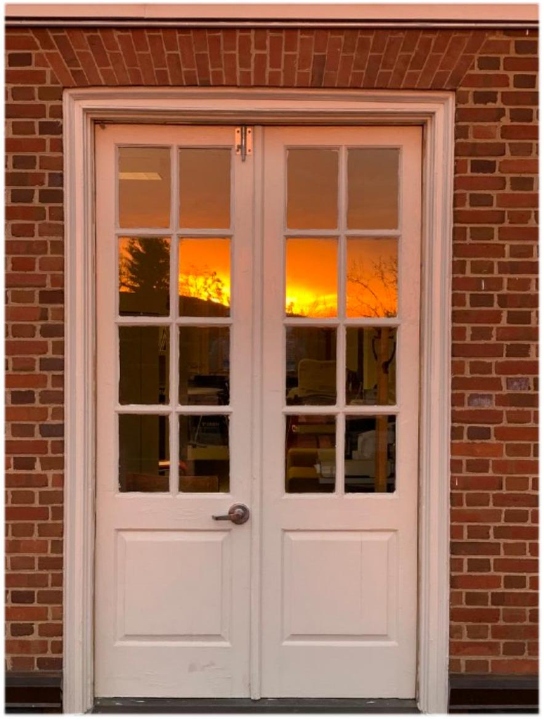

## Faculty Profile: Yen Do Promoted to Associate Professor

We are happy to announce that Yen Do has been promoted to an Associate Professor with tenure, effective August 2020. Congratulations to Yen on this milestone in his academic career!

Yen received his Ph.D. in Mathematics from the University of California, Los Angeles (2010) under the guidance of Christopher Thiele where the title of his dissertation was "A nonlinear stationary phase method for oscillatory Riemann-Hilbert problems". His first postdoctoral appointment (AY 2010-2011) was funded by the NSF and was split between Georgia Tech and the Institute for Advanced Studies at Princeton where his mentors were Michael Lacey and Jean Bourgain, respectively. This was followed by a three-year appointment as a Gibbs Assistant Professor at Yale where his mentors were Ronald Coifman, Peter Jones and Van Vu. Yen joined the Department of Mathematics at the University of Virginia in August 2014. The bulk of Yen’s research has been in the areas of harmonic analysis and probability.

Yen’s work in harmonic analysis has been primarily in the realm of time-frequency analysis–a central area of modern analysis focused on establishing boundedness of multilinear singular integral operators with additional symmetries. Singular integral operators are at the heart of harmonic analysis, and the study of singular integral

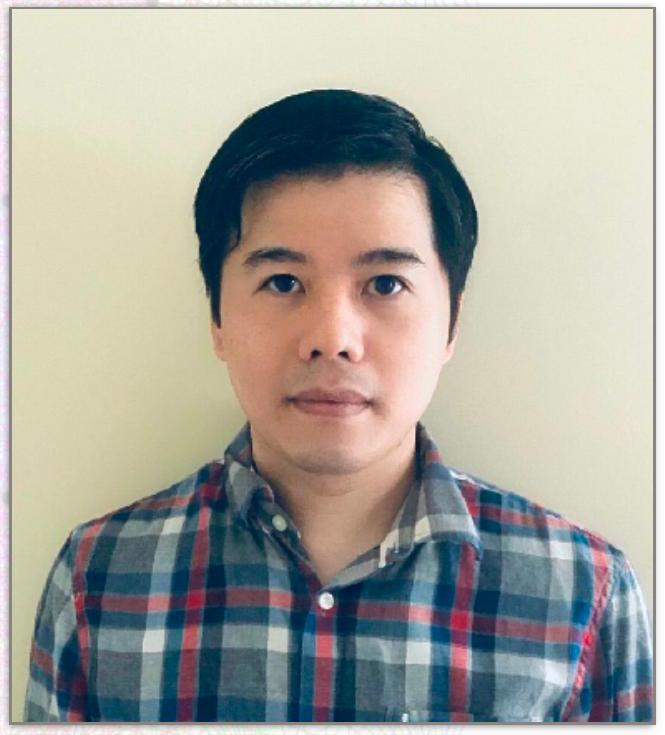

operators with modulation invariants is the key theme in the celebrated results of L. Carleson concerning the almost everywhere convergence of the Fourier series, and Lacey and Thiele concerning the boundedness of the bilinear Hilbert transform (conjectured by Calderon). Analytical techniques developed in these studies have found fruitful applications in other areas of mathematics, e.g., ergodic theory and mathematical physics. The following paragraph provides a sample of Yen’s work in this area.

In a foundational joint work with Thiele, Yen developed an $L^p$ theory for outer measures that greatly simplifies the highly technical nature of the time-frequency analysis. As an illustration of this approach, in a joint work with Di Plinio and Uraltsev, Yen obtained sharp weighted estimates for the variation-norm strengthening of the Carleson operator, improving his prior result with Lacey. The outer measure theory is especially useful for handling operators that are hybrids of the Carleson operator and the bilinear Hilbert transform. In this case, the classical theory relies on/features the nested levels of time-frequency analysis–a nearly prohibitive technical construction. The utility of Yen’s approach in this setting was demonstrated in a joint work with Muscalu and Thiele.

Yen’s work in probability has been mainly focused on the study of the asymptotic behavior of the roots of random polynomials (the coefficients are random variables). This is a classical theory founded at the beginning of the 20th century (Kac, Littlewood, Offord, Ibragimov and Maslova), experiencing a renewed interest; in particular, Tao and Vu developed a new framework adopting their methods from the theory of random matrices. The central questions here concern the asymptotics of the expected value of the number of real roots, the asymptotics of the variance of the number of real roots, and the asymptotic normality of the number of real roots (for the polynomials with large degrees, the distribution of the number of real roots is expected to be close to a Gaussian distribution). The following paragraph provides a sample of Yen’s work in this area.

An outstanding open problem in the field was to determine the leading asymptotics of the expected value of the number of real roots for a general flat random polynomial. In the mean-zero case (the coefficients have zero means), the problem was solved by Yen in a joint work with Vu and H. Nguyen. A much more challenging case of non-zero mean was then resolved by Yen (solo). In a recent work with Vu, Yen answered the questions about variance and asymptotic normality for the general flat random polynomials in the Gaussian setting (the coefficients are independent, identically distributed Gaussians).

Yen has also been very active in the mentoring realm. He has graduated one Ph.D. student (M. Lewers, with the thesis in the area of harmonic analysis), and is currently mentoring a Ph.D. candidate (N. Nguyen, with the thesis in the area of random polynomials) and a postdoc (G. Uraltsev, harmonic analysis). In addition, Yen has been a co-organizer of the departmental Harmonic Analysis and PDEs seminar.

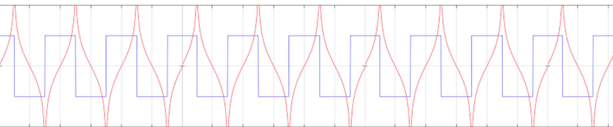

## Ono Advises UVA and US Olympic Swimming Team

For the last two years, Ken Ono has been working with the UVA and US Olympic Coach Todd DeSorbo, and dozens of members of the US National Swim Team. Together with US National Technical Coach Russell Mark, and UVA undergraduate research interns Jerry Lu, Paige Madden, and Margaret Michael, Ono has been analyzing high performance swimming using a battery of data analytics tools, and wavelet transforms applied to streams of data collected with waterproof accelerometers and gyroscopes. Combined with video analysis, Ono and his students have offered individualized adjustments in technique and strategy that helped optimize athletic performance. For example, these recommendations helped Madden drop 6 seconds in the 400m freestyle, earning her a coveted spot on the US Olympic team in the event alongside American Katie Ledecky.

The UVA Women’s Swim team won their first NCAA National Championship in 2021. Ono’s intern Madden won three individual NCAA national championships. On the international stage, he advised 15 members of the US Olympic Team that competed in Tokyo. Each of the 5 Olympians hailing from UVA won an Olympic Medal (3 silver medals and 2 bronze medals). Andrew Wilson, Ono’s last undergraduate thesis student at Emory, retired in Tokyo after winning a gold medal (Medley relay), and he is now a graduate student in mathematics at the Oxford University.

[figure not shown]

Caption: L-R: Ono, Emma Weyant (Silver medal 400 IM), Paige Madden (Silver medal $4 \times 200$ fr), Alex Walsh (Silver medal 200 IM), Jerry Lu

## UVA Math Circle

The Math Circle is an annual outreach program for elementary and middle school students, taking place on UVa grounds. The Fall 2021 program was the $5^{\text{th}}$ year of the UVa Math Circle, geared towards $4^{\text{th}}$ and $5^{\text{th}}$ grade students nominated by Charlottesville area schools.

The focus of the Math Circle is on learning mathematics through interactive exploration and solving challenging, non-standard problems. The goal is not to increase proficiency in routine curriculum skills, but rather to expose students to ideas

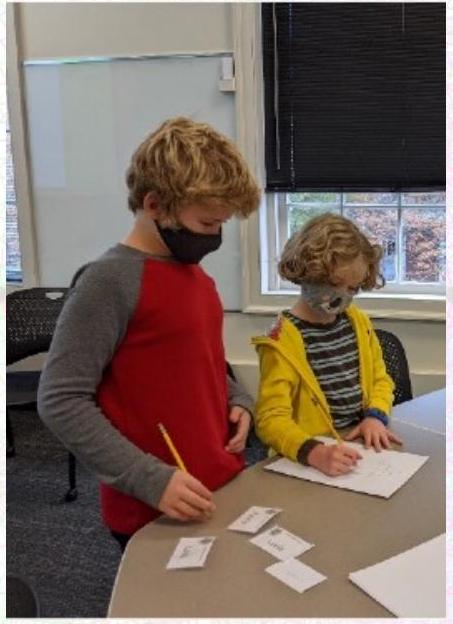

and concepts in math that encourage them to think creatively and generate interest in mathematics. Students learn topics and practice solving problems in diverse areas of mathematics, including geometry, combinatorics, logic, and number theory. Meetings involve working in small groups, as well as math games where students work in teams on fun, challenging problems.

Many of the topics discussed in the Math Circle are not part of the standard school curriculum. To give just one example, a popular math game in the program is "Hex," introduced in the 1940s by two mathematicians, Piet Hein and John Nash. It teaches students ideas in topology, combinatorics, and game theory. Another example of a fun activity involved exploration of hexaflexagons, a concept attributed to mathematician Arthur Stone and popularized by Martin Gardner. Students constructed hexaflexagons with various geometric patterns, and studied their (highly non-trivial!) combinatorics structure.

Another important aspect of the program is that it gives students an opportunity to meet their peers from other schools who share their interest in learning math. The meetings in Fall 2021 were led by professors Juraj Foldes and Slava Krushkal, with the assistance of Kristina Cernekova, Rostislav Akhmechet and Louisa Liles, all members of the UVa Math department. Further information about

[figure not shown]

the program is available at math.virginia.edu/mathcircle/.

## Undergraduate Program

### UVA Math Club

The UVA Undergraduate Math Club has been meeting on a weekly / bi-weekly schedule throughout the year. The meetings have been held in the Kerchof 3rd floor lounge on Tuesday afternoons. The faculty organizers are Evangelia Gazaki and Peter Humphries, and the student officers are Spencer Martin and Casia Siegel. The student members cover a wide range - from first-years interested in math to advanced fourth-year math majors. All of the participants share excitement for mathematics. Meetings generally begin with pizza and drinks and 15 minutes for social time. Math club events have included **math lectures** given by graduate students and faculty, **fun activities** like board games, movie nights, a pie day, and a math t-shirt design competition, and various **panel discussions**. Examples of panels include:

- **A grad school panel** in early fall. We assemble a panel consisting of faculty members with experience in graduate admissions and UVA alumni who have been admitted to top graduate programs in the U.S. and abroad.
- **Advice on course registration** shortly before course registration opens for the upcoming semester. We invite the director of undergraduate studies together with some more faculty members to give advice on courses and on the various different routes that lead to a math major.
- **A career/internship panel** in early spring. We assemble a panel consisting mostly of UVA alumni who have graduated with a math major and now work in various industry jobs ranging from finance, data science, consulting, to teaching institutions of various levels

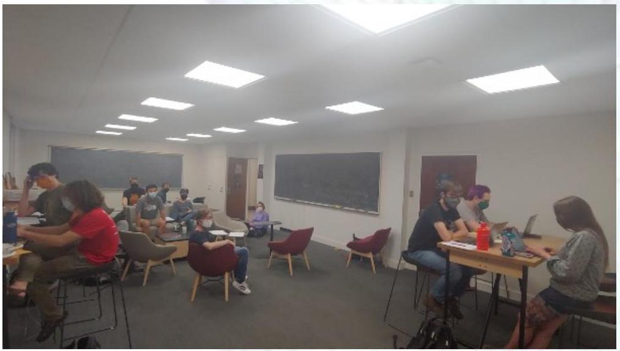

Some Math Club regulars, working in the 3rd floor lounge

### UVA Chapter of the Association for Women in Mathematics

The AWM (Association for Women in Mathematics) is a national organization whose goals are to create a community in which women and girls can thrive in their mathematical endeavors, and to promote equitable opportunity and treatment of women and others of marginalized genders and gender identities across the mathematical sciences. The UVa AWM student chapter has been active since the fall of 2016. This year, UVa AWM activities are led by our chapter President Casia Siegel and Vice President Catherine Cossaboom, with help from faculty mentors Ben Hayes and Tai Melcher.

The AWM chapter took advantage of the return to in-person instruction by kicking off the semester with an ice cream social. This was a wonderful opportunity to welcome new students to our community, and for returning students to catch up with math friends they hadn’t seen for three semesters, all accompanied by chocolate sauce and sprinkles.

In October, the AWM hosted a Lunch in the Lounge with colloquium speaker Della Dumbaugh. These speaker lunches are opportunities for our community to

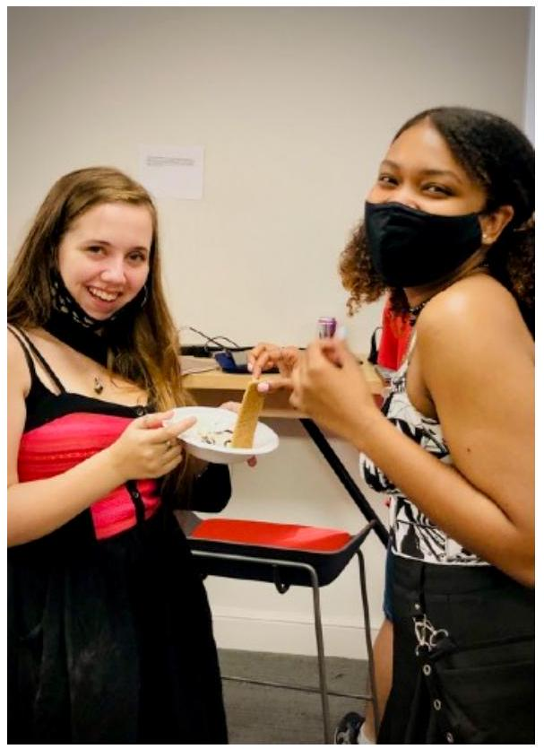

have informal interactions with women researchers visiting our department, and to hear more about their experience in mathematics and as academicians. Highlights of that conversation include Prof. Dumbaugh talking about her editorial work and what research in math history is like. Afterwards, she gave a fantastic colloquium on "Expect the Unexpected: Pioneers who Promoted Women in Math and Science".

Later in October, the AWM organized a movie night (with popcorn and snacks!), showing the 2020 documentary "Coded Bias", which explores how algorithms and artificial intelligence can discriminate based on race and gender. This film features discussions with (and work of) women researchers Joy Buolamwini, Deborah Raji, Meredith Broussard, Cathy O’Neil, Zeynep Tufekci, Safiya Noble, Timnit Gebru, Virginia Eubanks, and Silkie Carlo, among others. The viewing was followed by an informal discussion among the audience members of the issues raised in the film.

The AWM ended the fall semester with a festive holiday/math-themed cookie decorating study break on reading day, with cookies graciously provided by Catherine and Casia. Attendees got to enjoy both cookie decorating and eating (math-themed or otherwise) and were able to take a well-deserved break from finals studying (or grading, for the professors).

Though the omicron surge has created complications, the UVa AWM Student Chapter is still looking forward to hosting several in-person events this semester! Such events are important in providing a sense of community among our members, which is key in improving the participation and retention of historically excluded groups in our field. In February, the AWM will co-host an industry career panel with the UVa Math Club, to provide information to students on some career opportunities for people with mathematical training, and on how to best prepare oneself for these jobs. There will be another movie night later in the semester, with a viewing of "Picture a Scientist," a 2020 documentary that highlights gender issues in science. To close out the year, the AWM will provide another study break opportunity during reading day in the form of an (outdoor) ice cream social. Anyone who would like to know more about our AWM chapter or how to get involved, is invited to contact Tai Melcher (melcher@virginia.edu) and Ben Hayes (brh5c@virginia.edu). We hope to see you at future events!

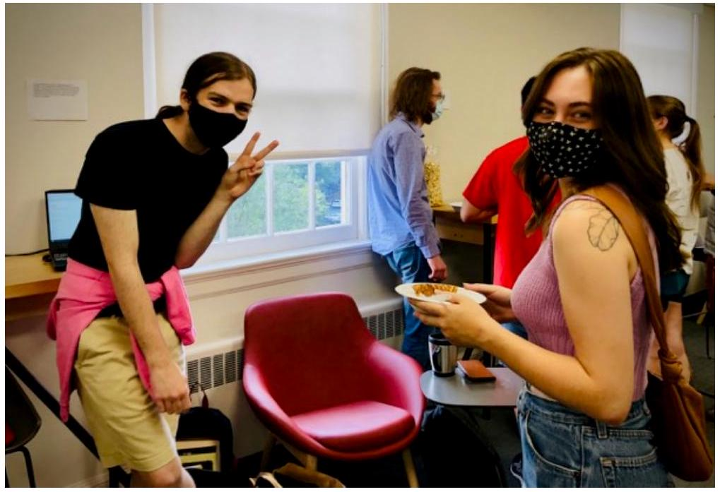

### UVA Research Experience for Undergraduates

In spite of the pandemic, the UVa Department of Mathematics again ran a vibrant program of summer research experiences for undergraduate students in June and July 2021. This had two parts: a program Number Theory and Representation Theory organized by Professor Ken Ono, with most of its funding coming from the National Security Agency, National Science Foundation and the Templeton World Charity Foundation, and a program Geometry and Topology organized by Professors Thomas Koberda, Slava Krushkal, Nick Kuhn, and Sara Maloni, and funded as an activity of the department’s Geometry and Topology Research Training Group (RTG) grant from the National Science Foundation.

The Number Theory and Representation Theory program had students from colleges and universities across the country, while the Geometry and Topology program was targeting students in the Mid-Atlantic region who had not previously had research opportunities. A diverse group of 19 men and 13 women were recruited as participants.

Although the pandemic necessitated significant changes to the planned program, the participants enjoyed many weeks of virtual research activities. These activities included outside lecturers zooming in from around the world for each program, various mini-courses, panel discussions, and in-depth guided research with UVa faculty and postdoctoral mentors, supported by UVa graduate students.

The mini-courses in the Number Theory and Representation Theory program were:

- Abelian Varieties (Instructor: Prof. Evangelia Gazaki)
- Diophantine Approximation (Instructor: Postdoc Jinbo Ren)
- Representation Theory of $S_n$ (Instructor: Prof. You Qi)

The mini courses in the Geometry and Topology were:

- An introduction to the fundamental group (Instructor: Walker Stern)
- Curves on surfaces (Instructor: Filippo Mazzoli)
- A crash course in knot theory (Instructor: William Olsen)

Lead mentors of the groups working in number theory were UVa Professors Peter Humphries and Ken Ono, UVa postdoctoral research associates Charlotte Ure and Wei-Lun Tsai, and Jesse Thorner (U. Illinois, Urbana Champaign). Lead mentors for the students working in topology were RTG postdocs Olsen and Stern, and Whyburn postdoc Mazzoli.

Working in groups of 3 or 4, the students focused on open research problems related to the concerns of modern research. Six months later, the research groups have written roughly a dozen papers submitted for publication, with titles ranging from Tamagawa products of elliptic curves over number fields to A finite equivariant generalization of motion planning and topological complexity. We are excited to see these students gaining experience with all aspects of the process of doing interesting research.

We are happy to report that many of our REU participants from previous years have done well earning fellowships and awards, and we single out for congratulations Letong (Carina) Hong, winner of the 2022 Alice T. Schafer prize and a Rhodes Scholarship.

UVa Mathematics is running a similar program in 2022 (see https://uva.theopenscholar.com/reu/program). Please spread the word.

## Undergraduate Recognition and Awards

We held a departmental graduation ceremony in May 2021 at which we recognized the accomplishments of our graduating majors, conferred degrees, and announced several special achievements and awards.

### Distinguished Majors Program 2021

Zachary Baugher was recognized for completion of the distinguished majors program, which involves extensive coursework, participation in research through the writing of a thesis and a final oral defense.

### Undergraduate Awards

Each year the department awards several prizes to undergraduate students. The E.E. Floyd Prize is awarded annually to math majors who show exceptional promise in mathematics. The E.J. McShane Prize is awarded annually to a graduating major of outstanding achievement in mathematics.

Both prizes come with a plaque and a small monetary award.

The 2021 winners of the E.E. Floyd Prize were: Zachary Carlini, Spencer Martin, Casia Siegel, Michael Stepniczka, and Sean Stuhlsatz.

The 2021 winner of the E.J. McShane Prize was: Zachary Baugher.

Congratulations to all!

### Eleven UVA Math Majors Elected to Phi Beta Kappa

Congratulations to Mingxuan Cai, Andrew Farquhar, William Foulds, Jin Lee, Hao Li, Aidan McManus, Lingnan Shen, Casia Siegel, Jackie Sublett, Darwin Walter, and Muyuan Wang.

As the oldest and most distinguished honor society in the country, Phi Beta Kappa offers membership to less than one percent of all undergraduates. Many of the leading figures in American history and culture have begun their careers with election to the society, including seventeen presidents of the United States. As a result, membership is a remarkable accomplishment, both for the student who achieves it and the faculty and staff whose support and guidance has led to this milestone.

### Distinguished Major Program 2022

#### David Winters

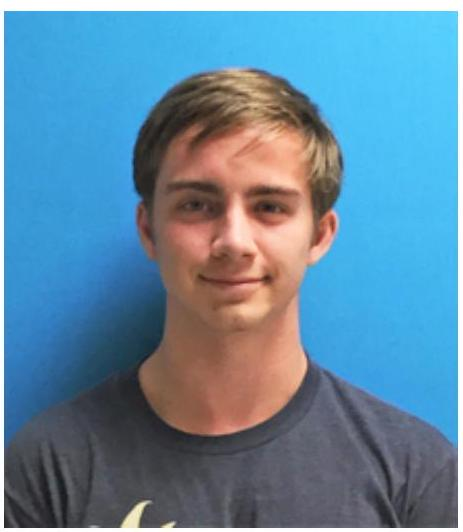

Advisor: You Qi

Title: Monoidal categories, diagrammatics and applications in topological field theories

This DMP project aims to investigate several diagrammatic calculi in the study of Hopf algebra representations, categorification, and quantum low-dimensional topology. Diagrammatic calculus originally arose in the works of theoretical physicists such as Feynman and Penrose. In recent years, these methods have found remarkable applications in mathematics, describing important monoidal categories in representation theory and quantum topology. The project will provide an overview of the diagrammatic calculus utilized in the celebrated $(2+1)$ dimensional Witten-Reshetikhin-Turaev topological quantum field theory and investigate related diagrammatic algebras.

#### Nathan Li

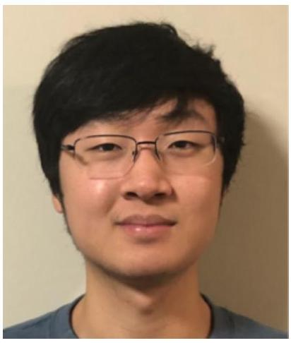

Advisor: Tom Mark  
Title: The $h$-cobordism theorem

A cobordism between two manifolds is a manifold whose boundary is the disjoint union of the two manifolds. With some stronger conditions, the existence of a cobordism between two manifolds implies they are isomorphic. This is the content of the $h$-cobordism theorem. The $h$-cobordism theorem is an important tool in the classification of manifolds, a key problem in topology, and it immediately answers the Poincaré conjecture in higher dimensions. The goal of this project is to present a proof of this theorem. We develop some basic Morse theory so we can obtain the handle decomposition of a manifold, a way of building up a manifold from smaller pieces. Once we have the handle decomposition of a cobordism, we can "simplify" the cobordism with its homology data.

#### William Winston

Advisor: Thomas Koberda

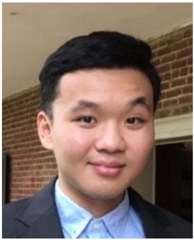

Title: Minimal and non-minimal diffeomorphisms of the circle

Consider an orientation-preserving homeomorphism of the circle. A classical dynamical invariant of this homeomorphism, originally introduced by Poincaré, is the rotation number, which measures the tendency of the homeomorphism to behave like a rotation of the circle. A homeomorphism with irrational rotation number may not be conjugate to a rotation through an irrational multiple of $\pi$ but a classical result of Denjoy says that if the homeomorphism is at least twice differentiable, then it is conjugate to an irrational rotation. There is a large body of literature investigating the conditions on the derivative of a diffeomorphism which guarantee that it is conjugate to an irrational rotation. We will discuss some of this literature, particularly Denjoy’s Theorem, a construction of differentiable counterexamples to Denjoy’s Theorem, and we will contextualize and clarify several results of Hu and Sullivan that furnish further constraints on the behavior of the derivative of a Denjoy counterexample.

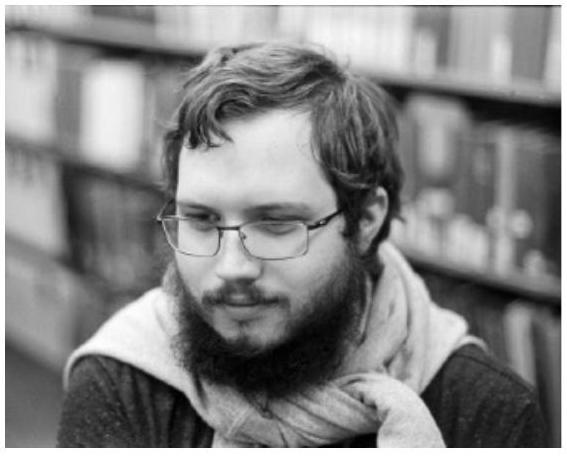

#### Spencer Martin

Advisor: Valia Gazaki  
Title: Arithmetic of elliptic curves

Elliptic curves form a rich class of algebro-geometric spaces with particularly nice properties and structures. Concretely, they are solutions to polynomial equations of the form $y^{2}=x^{3}+ax+b$ together with a point at infinity. Of particular interest is that the points on an elliptic curve have an addition law, turning it into an abelian group. The aim of the project is to give a taste of the rich and beautiful story of elliptic curves over fields of arithmetic interest. As we vary the base field $F$ to be a finite field, a $p$-adic field, or an algebraic number field, the structures of these $F$-rational points exhibit distinct but related behaviors, culminating in a sketch of a proof of the Mordell-Weil theorem: the rational points on an elliptic curve over a number field form a finitely generated abelian group.

## Graduate Program

### Bridge to the Doctorate Program

The UVa math department is in its second year of participation in the Bridge to the Doctorate, a two-year post-baccalaureate program funded by the graduate school. We provide academic training, research experience, and professional development for students from groups that are underrepresented in math, aiming to prepare them for admission to doctoral programs. With individualized mentoring from our faculty, students take a challenging slate of classes and participate in a wide range of workshops within and without the college.

In Fall 2021 we welcomed Luz Melo and Eloisa Sanchez as our second cohort, joining continuing students Adrian Avalos and Alex Jenny. We all appreciate being back in person! The bridge students have an office in Kerchof and can often be found working and socializing in the math lounge. Adrian and Alex are currently applying to math PhD programs for Fall 2022.

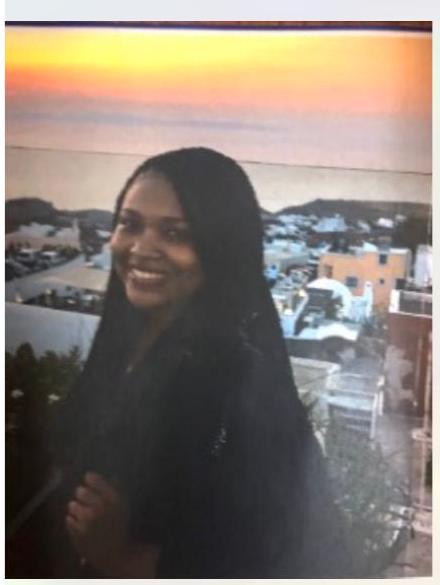

We asked Luz and Eloisa for their impressions so far, and both highlighted the opportunity to take advanced coursework. Eloisa wrote, "The bridge program has given me the opportunity to rise to a level of rigor that I was not exposed to during my undergraduate career". Luz said joining the Bridge "was one of the best decisions I’ve ever taken" and appreciated "the wide variety of courses and flexibility."

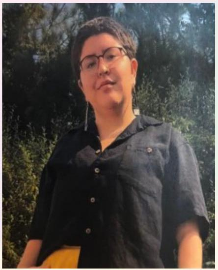

The math bridge program is administered by a committee of seven faculty. We welcome applicants for Fall 2022, so please pass the word on to any students or communities you think may be interested! The deadline for applications is March 1, and more information can be found at https://math.virginia.edu/graduate/bridge/, including a link to the application page in the graduate school. Inquiries may be directed to David Sherman (dsherman@virginia.edu).

### UVA Grad Student Award Winners

Peter Johnson was the winner of an **All-University Graduate Teaching Award**. Some of the highlights of his nomination included his success in teaching both the flipped-classroom model of calculus and in his efforts to make Financial Mathematics interesting and relevant for students even while taking the course virtually last year. Peter has also been involved in other teaching activities outside of the classroom, including working with the REU in topology and volunteering with the Math Circle.

Andrew Will was awarded a **UVA Mathematics Departmental Teaching Award**. His enthusiasm and genuine care for his students was particularly noted, as was his success in teaching in the flipped-classroom model. He also served as a teaching assistant for students doing an independent summer research project.

Aron Daw was awarded a **UVA Mathematics Departmental Teaching Award**. His nomination highlighted his ability to develop concepts effectively and engage the students, especially in a virtual course. It was noted that he actively promotes a growth mindset in his classroom and encourages his students.

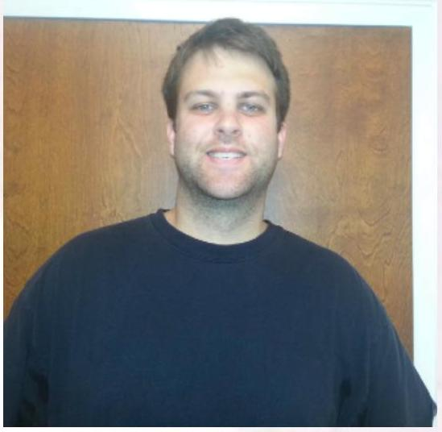

Peter Johnson

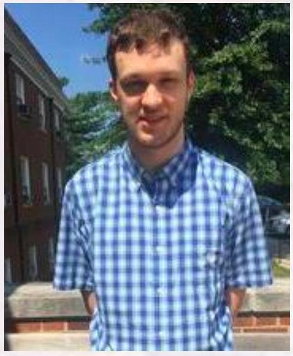

Andrew Will

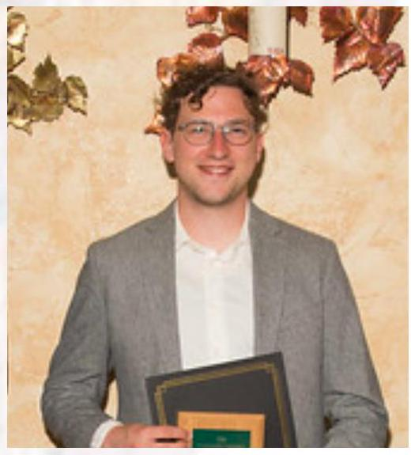

Aron Daw

### Spring 2021 Graduate Theses

#### Ian Runnels

Thesis: Right-angled Artin groups in mapping class groups

Advisor: Thomas Koberda

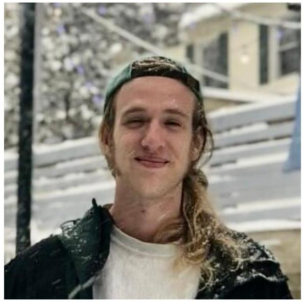

##### Thesis Abstract

In this thesis, Runnels studied the algebraic and geometric structure of subgroups of mapping class groups generated by suitably high powers of mapping classes. It was known from work of Koberda that under general hypotheses, given a finite collection of infinite order mapping classes on a surface, there is an exponent $N$ such that for any $n$ greater than or equal to $N$, the $n$-th powers of those mapping classes generate a right-angled Artin group. Here, right-angled Artin groups are a certain combinatorially determined family of groups which occurs in profusion within mapping class groups and throughout geometric group theory, and which played a central role in the resolution of the virtual Haken and virtual fibering conjectures in hyperbolic geometry. The isomorphism type of this right-angled Artin group obtained this way is the "expected" one, which is to say it is determined by the topological configuration of the supports of the corresponding mapping classes. The goal of this thesis was to construct an effective upper bound on the minimal value of $N$. Among the results in the thesis is the fact that, given a finite collection of Dehn twists about simple closed curves, the value of $N$ is at most $18$ plus the maximal geometric intersection number between two of the curves in the collection.

The thesis also develops and refines a number of technical tools adapted to the study of the coarse geometry of the curve graph, and shows that right-angled Artin subgroups of mapping class groups that are constructed in this way generally embed into the mapping class group in an undistorted fashion.

Upon graduating in May 2021, Runnels accepted a research-focused postdoctoral position at Vanderbilt University.

#### Chris Lloyd

Thesis: Applications of Chromatic Fixed Point Theory

Advisor: Nicholas Kuhn

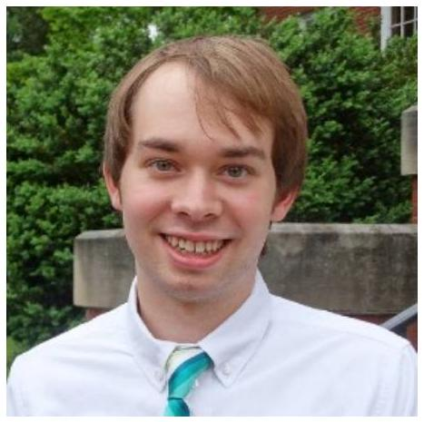

Chris has taken a job with the Federal Aviation Authority, studying data related to flight disruptions during extreme weather events.

##### Thesis Abstract

From its inception, the primary concern of algebraic topology has been using algebraic techniques to construct invariants of topological spaces. This pursuit has led to the creation of many important cross-disciplinary tools. One such modern tool is the equivariant Balmer spectrum associated to the $G$-equivariant stable homotopy category, when $G$ is a finite group. The study of this amounts to the study of following question: for what $(H, G, m, n)$ is it true that, whenever $X$ is a finite cell complex with a $G$-action, if $X^{H}$ is $K(m)_{*}$-acyclic then $X^{G}$ must be $K(n)_{*}$-acyclic? Here $H$ is a subgroup of the finite group $G$, $X^{G}$ is the space of $G$-fixed points of $X$ and $K(n)_{*}(Y)$ is the $n$th Morava $K$-theory (localized at a prime) of a space $Y$. This question can be interpreted as asking about generalizations of a classical theorem of P.A.Smith proved in 1941.

This thesis first describes how these generalized Smith theorems are equivalent to similar generalizations of a stronger theorem about fixed points proved by UVA professor E.E.Floyd in 1952. A first type of application of this is given: the problem above is answered when $G$ is the dihedral group of order $8$, the simplest case where previous work by others didn’t suffice.

Much of the thesis is study of $K(n)^{*}\left(\operatorname{Gr}_{d}\left(\mathbb{R}^{m}\right)\right)$, the $2$-local Morava $K$-theories of the real Grassmannians, about which very little has been previously computed. The Atiyah-Hirzebruch spectral sequences computing these are shown to often collapse after the first possible non-zero differential, and much evidence is given that this is always the case. To show that higher differentials can’t occur, a lower bound on the size of $K(n)^{*}\left(\operatorname{Gr}_{d}\left(\mathbb{R}^{m}\right)\right)$ is obtained by constructing a $C_{4}$-action on the Grassmannians and then applying the new generalized Floyd theorem.

#### George Henry Seelinger

Thesis: K-theoretic Catalan Functions

Advisor: Jennifer Morse

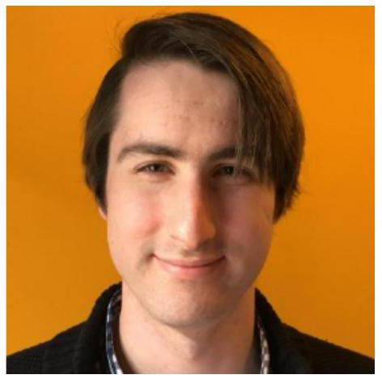

George Seelinger did his thesis in algebraic combinatorics, at the intersection of combinatorics, representation theory, and algebraic geometry via the study of symmetric functions. The algebra $\Lambda$ of multivariate symmetric functions has a rich combinatorial structure, which allows problems from other settings to be translated into problems about expressing a symmetric function as a non-negative linear combination of other bases of symmetric functions. These positivity problems can be split into two parts: (i) show a symmetric function expands in terms of a given basis with non-negative coefficients and (ii) give an explicit formula for the coefficients of this expansion. Seelinger’s research used and generalized new tools called *Catalan functions* to solve positivity problems with geometric and representation theoretic significance.

The framework of Catalan functions provided new proof methods for resolving conjectures about $k$-Schur functions, Schubert representatives for the homology of the affine Grassmannian for $\mathrm{SL}_{k+1}$. Seelinger and co-authors proved that the $K$-theoretic refinement, $K$-$k$-Schur functions, are part of a family of inhomogenous symmetric functions whose top homogeneous components are Catalan functions. Lam-Schilling-Shimozono identified the $K$-$k$-Schur functions as Schubert representatives for $K$-homology of the affine Grassmannian for $\mathrm{SL}_{k+1}$. Seelinger’s thesis reveals that the $K$-$k$-Schur functions satisfy a shift invariance property and deduces positivity of their branching coefficients. Further, Seelinger’s thesis shows that a slight adjustment of this new formulation for $K$-$k$-Schur functions produces a second shift-invariant basis satisfying a rectangle factorization property and that conjecturally has positive branching. Building on work of Ikeda-Iwao-Maeno, it is conjectured that this second basis gives the images of the Lenart-Maeno quantum Grothendieck polynomials under a $K$-theoretic analog of the Peterson isomorphism.

Seelinger accepted a three-year postdoctoral fellowship at the University of Michigan.

### Fall 2021 Graduate Thesis

#### Joseph Eisner

Thesis: Support Expansion Operator Algebras

Advisor: David Sherman

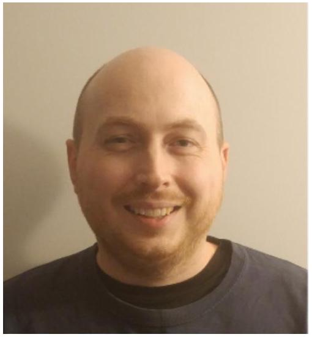

The collection of bounded operators on $\ell^{2}$ which have at most finitely many nonzero entries in each row and column of their standard array forms a $*$-subalgebra and thus their norm closure a $C^{*}$-algebra. Eisner’s dissertation generalizes this construction in several directions and settings, giving rise to a new general procedure for constructing *support expansion* $C^{*}$-algebras over a represented tracial von Neumann algebra. He gives a thorough analysis of the containment poset of support expansion $C^{*}$-algebras when the von Neumann algebra is taken to be $\ell^{\infty} \subset B\left(\ell^{2}\right)$ and when it is taken to be $L^{\infty}(\mathbb{R}) \subset B\left(L^{2}(\mathbb{R})\right)$. In particular, the latter poset has uncountable ascending and descending chains as well as uncountable antichains.

The $C^{*}$-algebra mentioned in the first sentence can be recognized as a *uniform Roe algebra*, a standard object in coarse geometry. In the second half of Eisner’s dissertation, he uses the measurable and quantum relations of Weaver, along with his home-baked intermediary cantankerous relations, to define *measurable, cantankerous* and *quantum uniform Roe algebras*. He then realizes the support expansion $C^{*}$-algebras developed in the first half as uniform Roe algebras in an appropriate sense.

Eisner defended his dissertation in December 2021 and will start a technical analyst position at the National Reconnaissance Office in February 2022.

## Celebrating Ira Herbst’s Distinguished UVA Career

Ira Herbst received his Ph.D. in Physics from the University of California, Berkeley in 1971. He held postdoctoral appointments in physics departments of the University of Michigan and Princeton University from 1971 to 1977. Ira joined the University of Virginia as an Assistant Professor in 1977, became an Associate Professor with tenure in 1979, and a Professor in 1983. He has served as Chair of the department from 2004 to 2007. Ira was selected for the inaugural (2013) class of Fellows of the AMS. Ira became Professor Emeritus in 2021.

His research has been mainly in the field of mathematical physics, and–in particular–in the mathematics of quantum mechanics. This includes his fundamental contributions to scattering theory, resonance theory of $N$-body systems, and non-relativistic quantum field theory. A recurring theme of his work in quantum mechanics has been the study of the systems subjected to external magnetic or electric fields. He has also written papers in relativistic quantum field theory, operator theory, fluid mechanics, and probability.

Ira has enjoyed a fruitful collaboration with many mathematicians–nationally and internationally–including Barry Simon, Yosi Avron, M. and T. Hoffmann-Ostenhof, Richard Froese, Erik Skibsted, Horea Cornean, and David Hasler. His discussions with the departmental colleagues resulted in the papers with Jim Howland, Tom Kriete and Shmuel Agmon (who was a half-time department member for several years).

He has received two awards for papers published in the prestigious Annals of Henri Poincare (AHP). One was a Distinguished Paper award in 2011 (with David Hasler), and the other one a Best Paper of the Year award (AHP Prize) in 2015 (with Julianne Rama). Both Hasler and Rama were postdocs in the department, illustrating Ira’s commitment to (and success in) mentoring junior mathematicians.

We look forward to his future research contributions and continuing departmental presence.

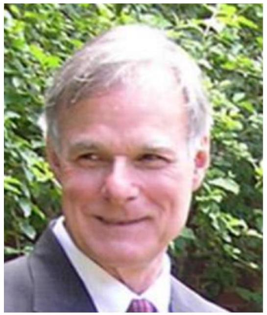

## IMS & Virginia Distinguished Lecturer

In Fall 2021, the Institute of Mathematical Sciences was able to partially resume its activities. Our featured event was the Fall 2021 installment of the Virginia Mathematics Lectures (VML) presented in the in-person format by the Fields medalist Curtis T. McMullen (Harvard University). Professor McMullen gave three lectures "Solving the Quintic by Iteration," "Billiards and Moduli Spaces," and "Rigidity for Planes in Flexible 3-Manifolds." The unifying theme for the three lectures was the rich interplay between complex analysis, dynamical systems, and algebraic geometry, with each topic motivated by fundamental and classical questions.

Professor McMullen’s presentations included superb quality graphics that illustrated complicated phenomena and made the ideas conveyed in the lectures understandable to people with a wide range of mathematical backgrounds. Consequently, all three lectures were well attended, with a diverse audience consisting of undergraduate and graduate students, postdocs, faculty, and emeriti. While at UVa, Professor McMullen made himself available to talk to members of the department through office hours.

The VML series was preceded by the 2021 Virginia Topology Conference on the subject of "Geometry and Dynamics in Hyperbolic Spaces", which featured eight plenary lectures on topics from homogeneous dynamics to the differential geometry of Lie groups to geometric group theory.

Our department is looking forward to the future installments of the VML series. The Distinguished Speakers in 2022 will be Mikhail Khovanov (Columbia University) and Martin Hairer (Imperial College London).

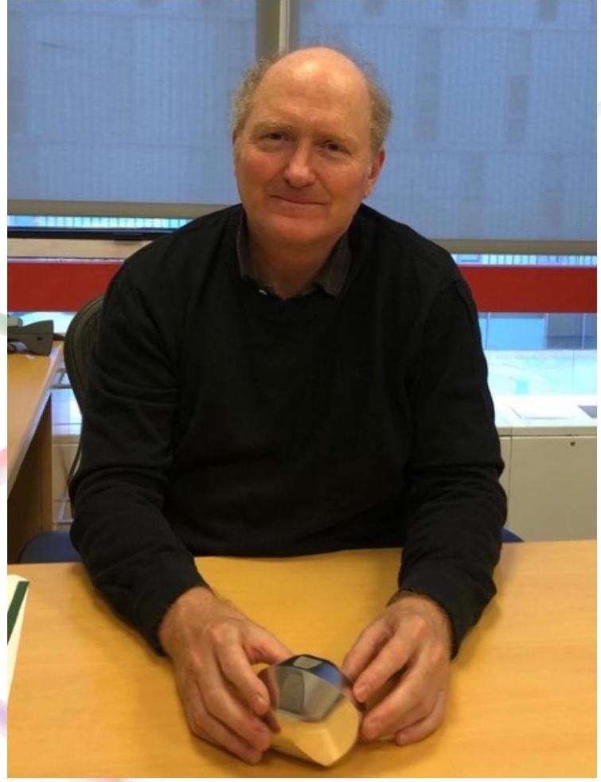

## In Memoriam: Brian Parshall

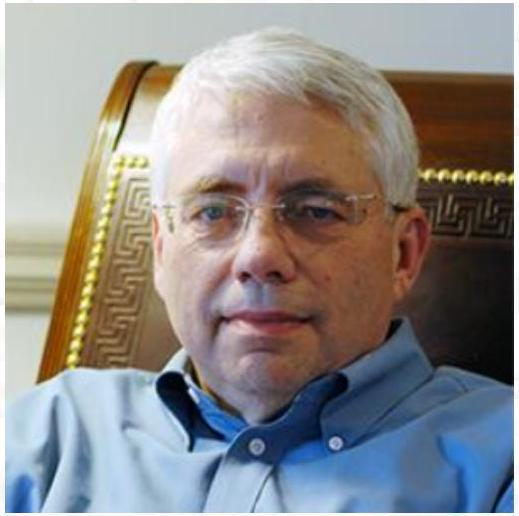

Our friend and colleague Brian Parshall passed away unexpectedly Monday morning (January 17th, 2022) from a non-COVID illness. He was admitted to the hospital a few days earlier, where he suffered several seizures from which he never recovered.

Especially noteworthy are Brian’s research collaborations. One famous collaboration, known as CPS, for Edward Cline, Brian Parshall, and Leonard Scott, created its first joint research publication at UVa in 1972-73. Brian’s research was in representation theory and the cohomology of algebraic and quantum groups, as well as of finite dimensional Lie and associative algebras. He published over 100 articles and mentored 9 Ph.D. students, and he helped found the annual Southeastern Lie Theory conferences.

To celebrate and honor his life, Brian would have welcomed donations in his memory to

- BROOD = Basset Rescue of Old Dominion (Website https://brood-va.org/ The donation button is at the end of the site).
- Hospice of the Piedmont. They were incredibly kind and caring. (Website: https://www.hopva.org/ and the donation button is at the top).

## Milestones

Cassandra Hill (UVa Math BA 1994) has been named Dean of the Northern Illinois University College of Law.

Gabriel Islambouli (UVa PhD 2019), who wrote his thesis under Slava Krushkal, is a Krener Assistant Professor at UC Davis.

Jinbo Ren, an Algebra postdoc (2018-2021) mentored by Andrei Rapinchuk, has been a member in the School of Mathematics at the Institute for Advanced Study for the 2021-2022 academic year. After his IAS membership, Ren will assume a tenure track assistant professorship at the Yau Mathematical Sciences Center at Tsinghua University in Beijing.

Axel Saenz Rodriguez, a Probability postdoc (2016-2019) mentored by Leo Petrov, is now a tenure track assistant professor at Oregon State.

Sarah Shalf (UVa Math BA 1994) has joined the UVa Law School as a Professor of Law (General Faculty), and Director of Clinical Programs.

Jonathan Simone (Va Math PhD 2018), who wrote his thesis under Tom Mark, has started a postdoc at Georgia Tech.

Bulent Tosun, a UVa Topology postdoc (2013-2016) mentored by Tom Mark, has been awarded an NSF Career Award. Tosun is a tenure track assistant professor at the University of Alabama.

Michael Willis (UVa PhD 2017), who wrote his thesis under Slava Krushkal, has accepted a tenure track assistant professorship at Texas A&M University.

## Thank you to all current and former members of the UVA Math community!

What are you up to? We’d love to hear from you! email: math-newsletter@virginia.edu

## Photos from Around Kerchof

Math Dept. Halloween Party!

[figure not shown]

Gennady (left) prepared a mathematical skit for his Basic Real Analysis students. David, Zach and Casia took part, all dressed as characters from the cartoon "Adventure Time".

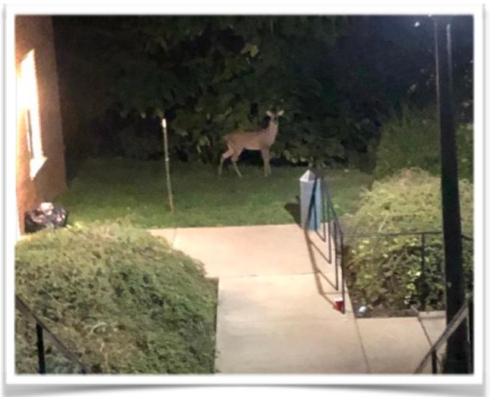

[figure not shown]

The essentials...

A nighttime visitor to Kerchof

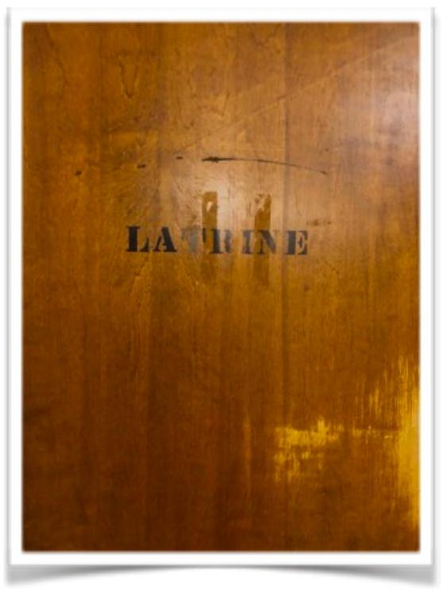

Kerchof’s iconic bathroom doors